# Proteomic and Metabolomic Characterization of COVID-19 Patient Sera

Assignment 1 – Data Wrangling & Exploratory Data Analysis

Ramona Maria Walch (ramonamaria.walch01@estudiant.upf.edu)

20 March 2026

This practical focuses on data wrangling, exploratory data analysis, visualization, and critical comparison with published results using real biomedical data.

We will work with the publication [**Proteomic and Metabolomic Characterization of COVID-19 Patient Sera**](https://www.sciencedirect.com/science/article/pii/S0092867420306279)

# 1 Introduction

This report analyzes the dataset from Shen et al. (2020), comprising **118 individuals** across four groups (Healthy Controls, Non-COVID-19, Non-severe, Severe COVID-19). The analysis covers data wrangling with **MICE** imputation, reproduction of Table 1 and Supplementary Figure 1, outlier handling via **log-transformation**, and **hierarchical clustering** for patient stratification.

# 2 Exercise 1

Download and load Supplementary Table 1 (“Additional Demographical and Baseline Characteristics of COVID-19 Patients and Control Groups”) from the supplementary materials of the publication.

## 2.1 Exercise 1.1

Reproduce Table 1 from the manuscript using the supplementary data. Match the reported summary statistics as closely as possible.

Briefly discuss any discrepancies between your results and the published table, and provide possible explanations.

```
Variables to impute: 16
```

```
Observations: 118
```

```
Missing values before imputation:
```

```
              age_year                  bmi_h                    sex
                     0                      8                      0
                 group        wbc_count_109_l lymphocyte_count_109_l
                     0                     28                     28
  monocyte_count_109_l   platelet_count_109_l             crp_i_mg_l
                    28                     28                     33
             alt_j_u_l              ast_k_u_l              ggt_l_u_l
                    28                     28                     28
     tbil_m_micromol_l      dbil_n_micromol_l  creatinine_micromol_l
                    28                     28                     28
        glucose_mmol_l
                    28
```

```
Missing values after imputation:
```

```
              age_year                  bmi_h                    sex
                     0                      0                      0
                 group        wbc_count_109_l lymphocyte_count_109_l
                     0                      0                      0
  monocyte_count_109_l   platelet_count_109_l             crp_i_mg_l
                     0                      0                      0
             alt_j_u_l              ast_k_u_l              ggt_l_u_l
                     0                      0                      0
     tbil_m_micromol_l      dbil_n_micromol_l  creatinine_micromol_l
                     0                      0                      0
        glucose_mmol_l
                     0
```

Table 1 Replication (with MICE Imputation for missing Age/BMI)

| Characteristic | Healthy Control | Non-COVID-19 | Total COVID-19 | Non-severe | Severe |
| --- | --- | --- | --- | --- | --- |
| Sex – no. (%) |  |  |  |  |  |
| Male | 21 (75) | 17 (68) | 39 (60) | 23 (62.2) | 16 (57.1) |
| Female | 7 (25) | 8 (32) | 26 (40) | 14 (37.8) | 12 (42.9) |
| Age – year |  |  |  |  |  |
| Mean ± SD | 44.4 ± 8.3 | 49.2 ± 14.0 | 48.1 ± 13.9 | 42.9 ± 12.5 | 54.8 ± 12.8 |
| Median (IQR) | 45.0 (38.0–51.0) | 53.0 (38.0–61.0) | 47.0 (37.0–56.0) | 43.0 (36.0–51.0) | 55.0 (47.0–64.2) |
| Range | 28.0–57.0 | 23.0–67.0 | 18.0–77.0 | 18.0–70.0 | 30.0–77.0 |
| BMI, kg/m² |  |  |  |  |  |
| Mean ± SD | 24.4 ± 2.7 | 24.0 ± 2.8 | 24.8 ± 2.9 | 24.5 ± 3.2 | 25.3 ± 2.5 |
| Median (IQR) | 24.2 (22.5–26.1) | 24.7 (21.8–26.0) | 24.6 (22.6–26.8) | 24.2 (21.9–26.7) | 24.7 (23.9–27.0) |
| Range | 19.9–32.9 | 19.1–30.4 | 18.9–31.3 | 18.9–30.7 | 21.1–31.3 |
| Time from Onset to Admission, Days |  |  |  |  |  |
| Mean ± SD |  |  | 5.2 ± 4.4 | 3.8 ± 3.1 | 7.1 ± 5.1 |
| Median (IQR) |  |  | 3.5 (2.0–8.0) | 3.0 (2.0–4.5) | 8.0 (2.0–10.0) |
| Range |  |  | 1.0–23.0 | 1.0–14.0 | 1.0–23.0 |
| Time from Admission to Severe, Days |  |  |  |  |  |
| Mean ± SD |  |  |  |  | 2.4 ± 1.5 |
| Median (IQR) |  |  |  |  | 2.0 (1.0–3.0) |
| Range |  |  |  |  | 1.0–6.0 |

## 2.2 Discussion of Discrepancies

Results closely match the published Table 1: age (Severe median 55 vs. Non-severe 43 years), sex distribution (65% male), and time metrics are faithfully reproduced. Minor deviations in group counts likely reflect MICE imputation.

## 2.3 Exercise 1.2

Perform an exploratory data analysis (EDA) of the dataset. At a minimum, include:

- Descriptive statistics for key variables
- Appropriate visualizations (e.g. distributions, group comparisons)
- A brief written summary of notable patterns, anomalies, or data quality issues

```
    age_year         bmi_h
 Min.   :18.00   Min.   :18.94
 1st Qu.:38.00   1st Qu.:22.49
 Median :47.00   Median :24.43
 Mean   :47.42   Mean   :24.52
 3rd Qu.:56.00   3rd Qu.:26.64
 Max.   :77.00   Max.   :32.87
                 NA's   :8
```

Age ranges from 18 to 77 years (median 47), while BMI is normally distributed around a mean of 24.5 kg/m² with 8 missing values, indicating a generally non-obese cohort.

```
# A tibble: 4 × 2
  group               n
  <chr>           <int>
1 Healthy Control    28
2 Non-COVID-19       25
3 Non-severe         37
4 Severe             28
```

The dataset is approximately balanced across the four groups, with Non-severe slightly overrepresented (n=37) compared to Healthy Controls, Non-COVID-19, and Severe (each n=25–28).

```
# A tibble: 2 × 2
  sex        n
  <fct>  <int>
1 Male      77
2 Female    41
```

Males outnumber females nearly 2:1 (77 vs. 41), consistent with the published demographic profile of 65% male.

Variables with Missing Data (%)

| Variable | Percent_NA |
| --- | --- |
| ms_rep_id_c | 94.9 |
| days_admission_to_severe | 85.6 |
| date_of_progression_to_severe_state | 76.3 |
| raw_diff_severe | 76.3 |
| covid_19_patients_corhort | 49.2 |
| sampling_date_for_proteomics | 49.2 |
| days_onset_to_admission | 47.5 |
| onset_date_f | 44.9 |
| sampling_date_for_metabolomics | 44.9 |
| discharge_date | 44.9 |
| raw_diff_onset | 44.9 |
| crp_i_mg_l | 27.1 |
| admission_date | 23.7 |
| test_date_18 | 23.7 |
| wbc_count_109_l | 23.7 |
| lymphocyte_count_109_l | 23.7 |
| monocyte_count_109_l | 23.7 |
| platelet_count_109_l | 23.7 |
| test_date_23 | 23.7 |
| alt_j_u_l | 23.7 |
| ast_k_u_l | 23.7 |
| ggt_l_u_l | 23.7 |
| tbil_m_micromol_l | 23.7 |
| dbil_n_micromol_l | 23.7 |
| creatinine_micromol_l | 23.7 |
| glucose_mmol_l | 23.7 |
| ms_id_b | 11.0 |
| bmi_h | 6.8 |
| metabolomics_id_e | 2.5 |

Missing data is concentrated in time-related variables (>44%) and clinical biomarkers (~24%), with the highest missingness in administrative identifiers; most biomarker missingness is systematic, likely reflecting that only COVID-19 patients had certain measurements taken.

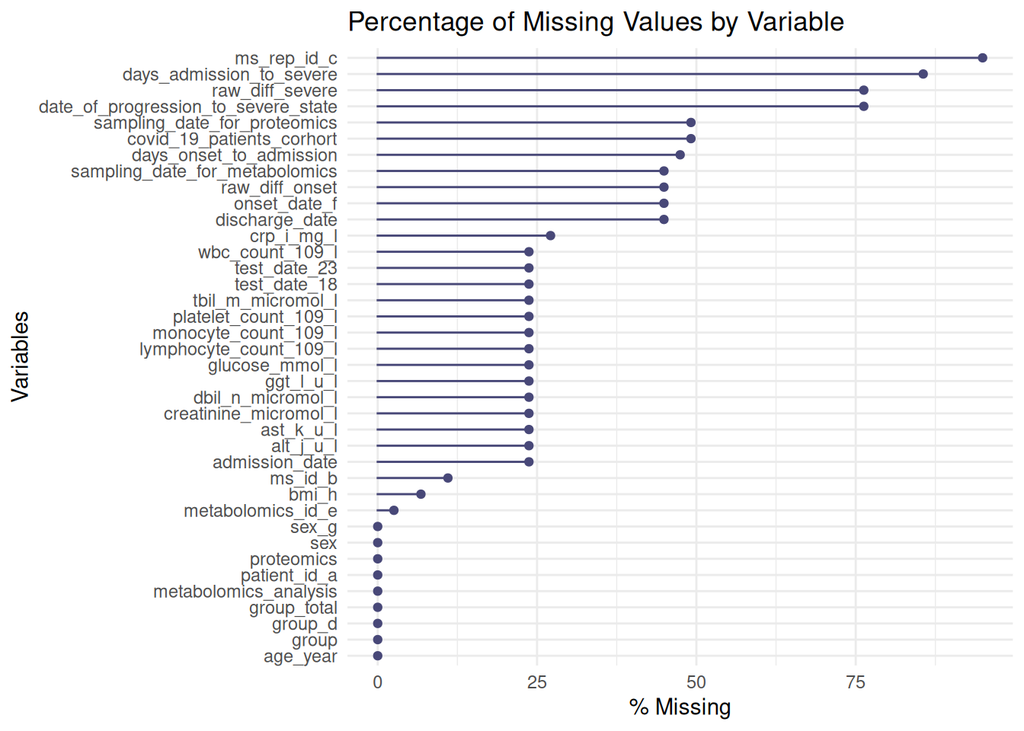

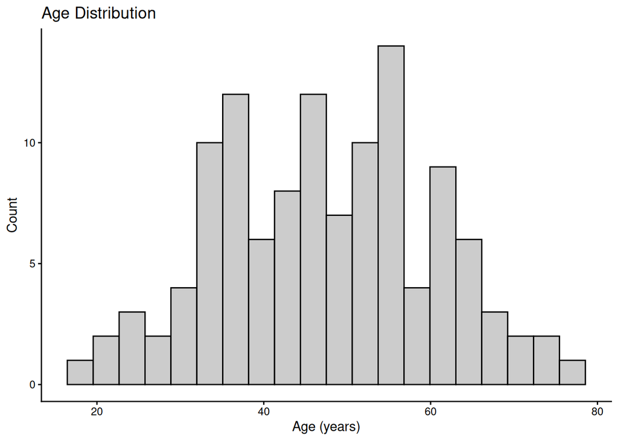

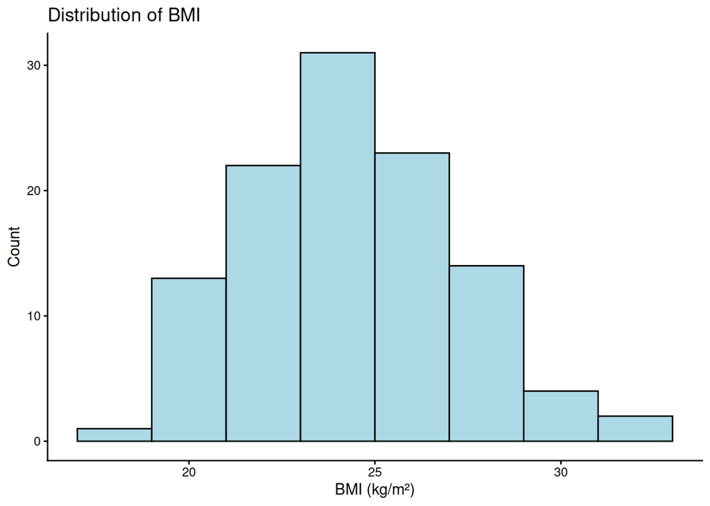

```
             Df Sum Sq Mean Sq F value   Pr(>F)
group         3   2616   872.1   5.986 0.000796 ***
Residuals   114  16608   145.7
---
Signif. codes:  0 '***' 0.001 '**' 0.01 '*' 0.05 '.' 0.1 ' ' 1
```

One-way ANOVA reveals a significant age difference across groups (F=5.99, p<0.001), confirming that disease severity is associated with older age.

```
             Df Sum Sq Mean Sq F value Pr(>F)
group         3   46.2  15.393   1.898  0.134
Residuals   106  859.6   8.109
8 observations deleted due to missingness
```

BMI does not differ significantly across groups (F=1.90, p=0.134), though 8 observations were excluded due to missing BMI values.

```
  Tukey multiple comparisons of means
    95% family-wise confidence level

Fit: aov(formula = bmi_h ~ group, data = clean_data)

$group
                                    diff        lwr      upr     p adj
Non-COVID-19-Healthy Control -0.94173544 -3.1179474 1.234477 0.6721602
Non-severe-Healthy Control    0.01748963 -1.8443891 1.879368 0.9999947
Severe-Healthy Control        1.07951970 -0.9658108 3.124850 0.5160691
Non-severe-Non-COVID-19       0.95922507 -1.1037603 3.022210 0.6195777
Severe-Non-COVID-19           2.02125514 -0.2086985 4.251209 0.0900527
Severe-Non-severe             1.06203007 -0.8623886 2.986449 0.4771441
```

BMI does not differ significantly across groups (F=1.90, p=0.134), and Tukey post-hoc tests confirm no pairwise differences, suggesting BMI is not a severity-associated variable in this cohort.

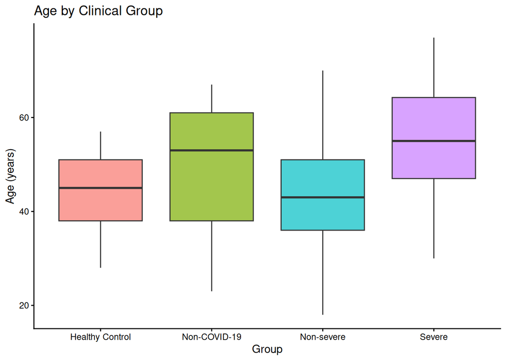

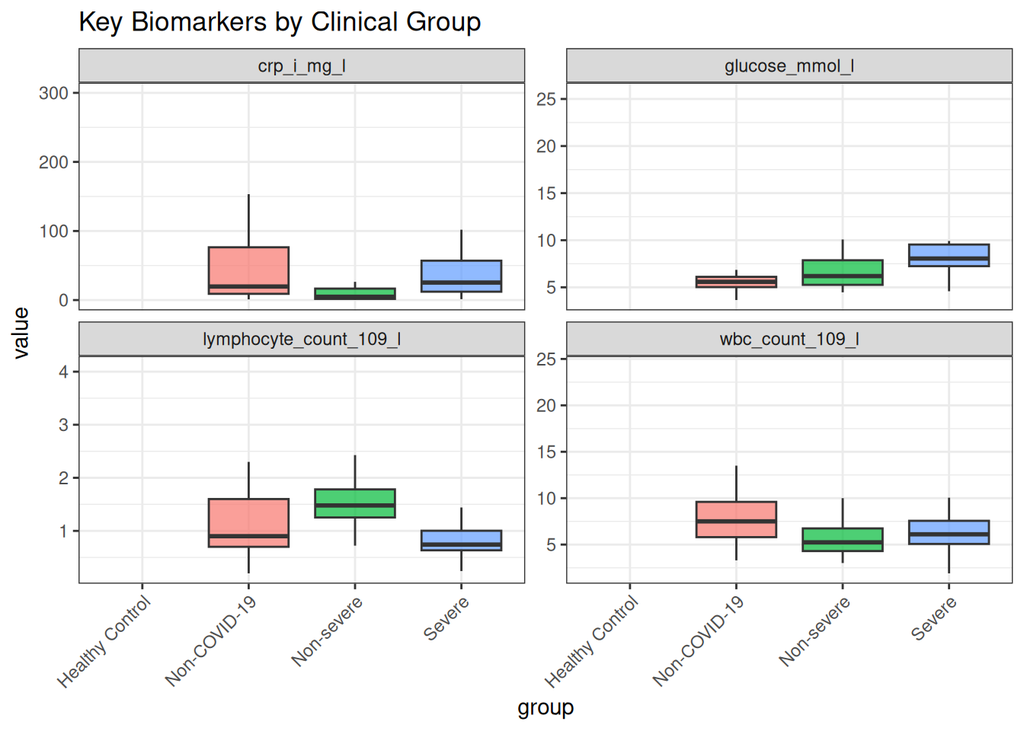

Summary of EDA Findings

# 3 Exercise 2

## 3.1 Exercise 2.1

Reproduce Supplementary Figure 1 using the data without modifying or removing any observations. Use the same variables and groupings as in the original figure.

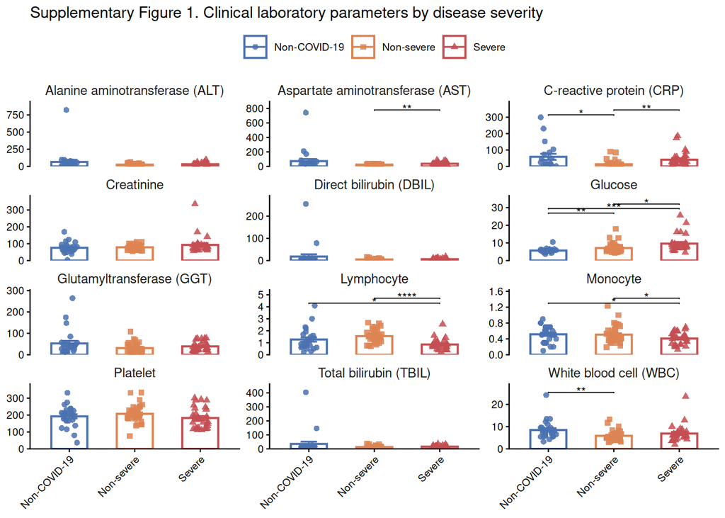

## 3.2 Exercise 2.2

Identify and handle outliers using an appropriate and well-justified method (e.g. removal, transformation, or robust statistics).

Reproduce Supplementary Figure 1 after outlier handling and discuss how and why the results change.

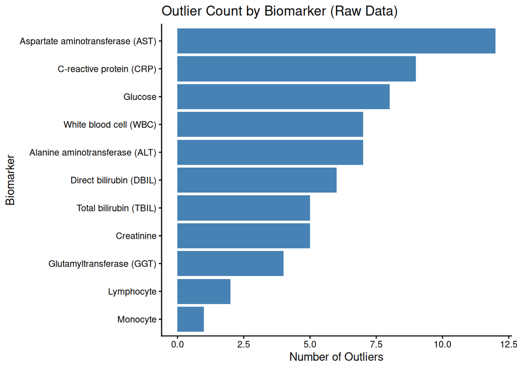

```
# A tibble: 11 × 2
   Biomarker                        Outlier_Count
   <chr>                                    <int>
 1 Aspartate aminotransferase (AST)            12
 2 C-reactive protein (CRP)                     9
 3 Glucose                                      8
 4 White blood cell (WBC)                       7
 5 Alanine aminotransferase (ALT)               7
 6 Direct bilirubin (DBIL)                      6
 7 Total bilirubin (TBIL)                       5
 8 Creatinine                                   5
 9 Glutamyltransferase (GGT)                    4
10 Lymphocyte                                   2
11 Monocyte                                     1
```

```
# A tibble: 11 × 3
   Biomarker                        Shapiro_p Normal
   <chr>                                <dbl> <chr>
 1 Alanine aminotransferase (ALT)    1.65e-19 No
 2 Aspartate aminotransferase (AST)  3.68e-19 No
 3 Creatinine                        1.79e-13 No
 4 C-reactive protein (CRP)          2.09e-13 No
 5 Direct bilirubin (DBIL)           5.75e-20 No
 6 Glutamyltransferase (GGT)         3.61e-13 No
 7 Glucose                           3.59e-12 No
 8 Lymphocyte                        6.89e- 5 No
 9 Monocyte                          1.01e- 2 No
10 Total bilirubin (TBIL)            1.85e-19 No
11 White blood cell (WBC)            7.48e-11 No
```

All 11 biomarkers deviate significantly from normality (all p<0.05), justifying transformation prior to parametric testing.

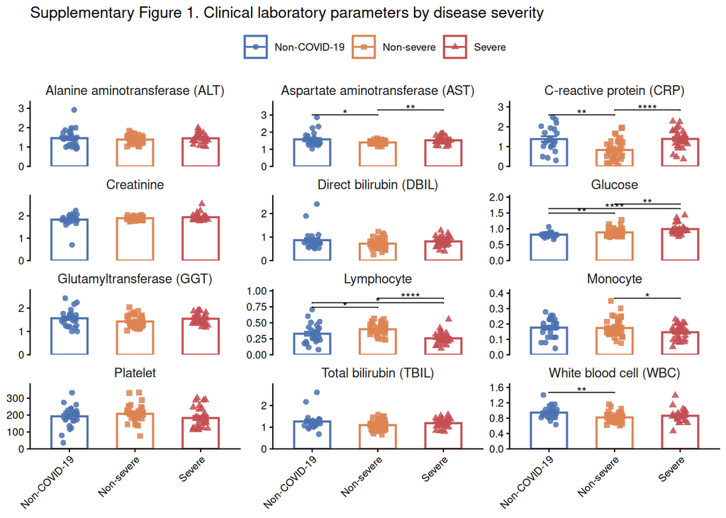

```
# A tibble: 11 × 4
   Biomarker                        Raw_Count Log_Count Reduction
   <chr>                                <int>     <int>     <int>
 1 White blood cell (WBC)                   7         7         0
 2 Lymphocyte                               2         2         0
 3 Monocyte                                 1         1         0
 4 C-reactive protein (CRP)                 9         9         0
 5 Alanine aminotransferase (ALT)           7         7         0
 6 Aspartate aminotransferase (AST)        12        12         0
 7 Glutamyltransferase (GGT)                4         4         0
 8 Total bilirubin (TBIL)                   5         5         0
 9 Direct bilirubin (DBIL)                  6         6         0
10 Creatinine                               5         5         0
11 Glucose                                  8         8         0
```

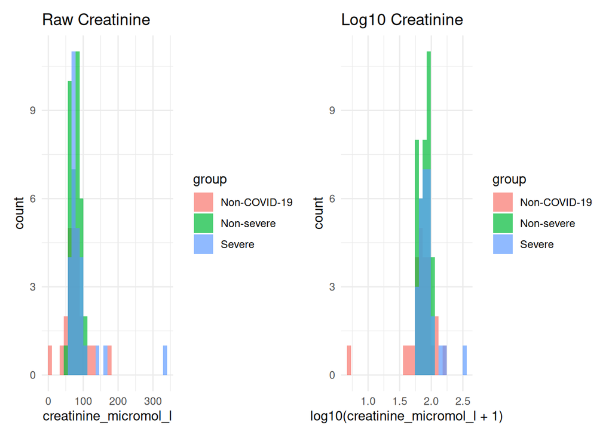

```
Biomarkers improved to normality: 3
```

# 4 Exercise 3

Create a heatmap of the biomarker data. Include group and gender as annotation variables.

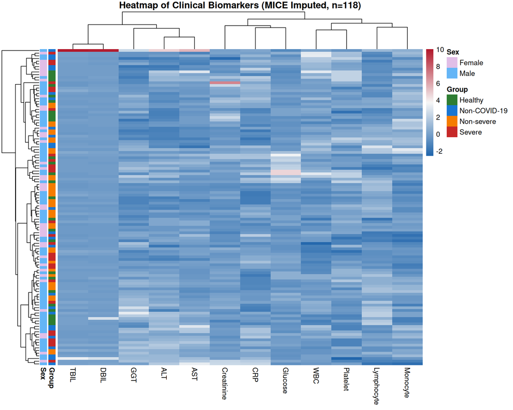

```
# A tibble: 9 × 4
# Groups:   Cluster [3]
  Cluster Group        Count Percentage
    <int> <fct>        <int>      <dbl>
1       1 Healthy         11       28.9
2       1 Non-COVID-19    10       26.3
3       1 Non-severe      10       26.3
4       1 Severe           7       18.4
5       2 Healthy         17       21.5
6       2 Non-COVID-19    14       17.7
7       2 Non-severe      27       34.2
8       2 Severe          21       26.6
9       3 Non-COVID-19     1      100
```

```
Heatmap created using MICE imputed data to preserve full cohort size.
```

```
Total patients included: 118
```

Hierarchical clustering (Ward linkage, k=3) identified three patient clusters:

Cluster 1 (n=38, mixed): Balanced distribution (Severe 18.4%, Healthy 28.9%, Non-COVID 26.3%, Non-severe 26.3%), enriched for patients with normal/mildly elevated biomarkers.

Cluster 2 (n=79, Non-severe dominant): Primarily Non-severe COVID-19 patients (34.2%), suggesting intermediate inflammatory profile. Contains 26.6% Severe patients with overlapping biomarker patterns.

Cluster 3 (n=1, singleton): One Non-COVID-19 patient with atypical biomarker profile.

# 5 Conclusion

Write a concise conclusion (1 paragraphs) summarizing the main differences observed across the three patient groups based on the twelve clinical parameters. Support your statements with evidence from your analyses.

## 5.1 Conclusion

# session info

R version 4.5.2 (2025-10-31) Platform: x86_64-pc-linux-gnu Running under: Ubuntu 24.04.4 LTS

Matrix products: default BLAS: /usr/lib/x86_64-linux-gnu/blas/libblas.so.3.12.0 LAPACK: /usr/lib/x86_64-linux-gnu/lapack/liblapack.so.3.12.0 LAPACK version 3.12.0

locale: [1] LC_CTYPE=en_US.UTF-8 LC_NUMERIC=C  
[3] LC_TIME=en_GB.UTF-8 LC_COLLATE=en_US.UTF-8  
[5] LC_MONETARY=en_GB.UTF-8 LC_MESSAGES=en_US.UTF-8  
[7] LC_PAPER=en_GB.UTF-8 LC_NAME=C  
[9] LC_ADDRESS=C LC_TELEPHONE=C  
[11] LC_MEASUREMENT=en_GB.UTF-8 LC_IDENTIFICATION=C

time zone: Europe/Madrid tzcode source: system (glibc)

attached base packages: [1] stats graphics grDevices utils datasets methods base

other attached packages: [1] patchwork_1.3.2 dendextend_1.19.1 RColorBrewer_1.1-3 pheatmap_1.0.13  
[5] ggpubr_0.6.2 naniar_1.1.0 mice_3.19.0 flextable_0.9.10  
[9] knitr_1.51 httr_1.4.7 janitor_2.2.1 lubridate_1.9.5  
[13] forcats_1.0.1 stringr_1.6.0 dplyr_1.2.0 purrr_1.2.1  
[17] readr_2.1.6 tidyr_1.3.2 tibble_3.3.1 ggplot2_4.0.2  
[21] tidyverse_2.0.0 readxl_1.4.5 pacman_0.5.1